# What’s Happening In Your Inbox?

An exploration of the ins and outs of my emails, an often overlooked yet fundamental part our day-to-day lives.

## When do I actually deal with emails?

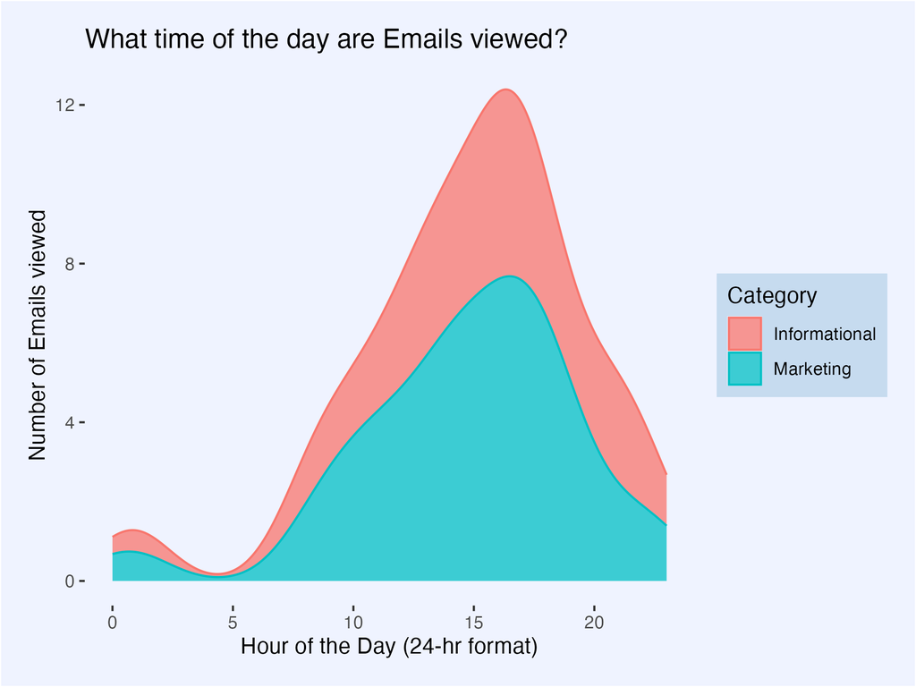

A plot with each hour of the day on the x-axis and the number of emails received during that hour on the y-axis. Density plots are stacked upon each other, each representing the data for a different category of email.

Most of the emails are distributed between daylight hours, but the tail ends follow my waking hours. Each category appears to follow a similar distribution centered between 3-5pm. Marketing emails appear to be the most common category, as it is the taller section throughout the graph.

## Which days was I disturbed the most?

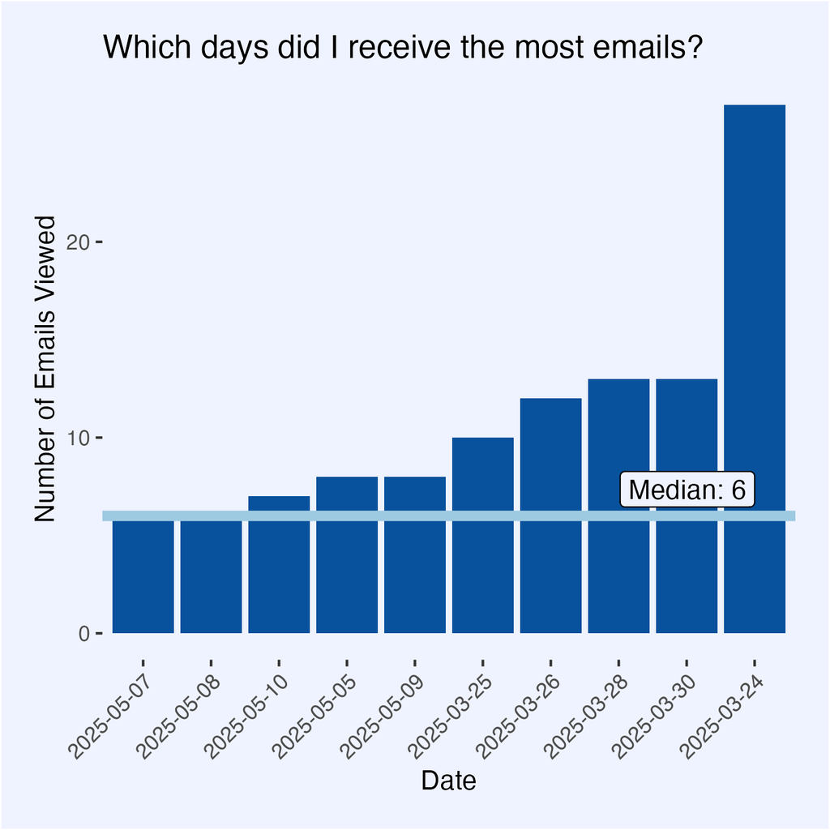

A bar graph showing the top 10 days where the most emails were viewed on. The y-axis represents number of emails viewed and the x-axis is the date. The median is shown as a horizontal line across the graph.

We can see there that there was a significantly elevated day, where the number of emails viewed was around quadruple the median. This suggests that there was likely a back-and-forth conversation that does not normally occur.

## Did the significance of the email change how long it takes to view?

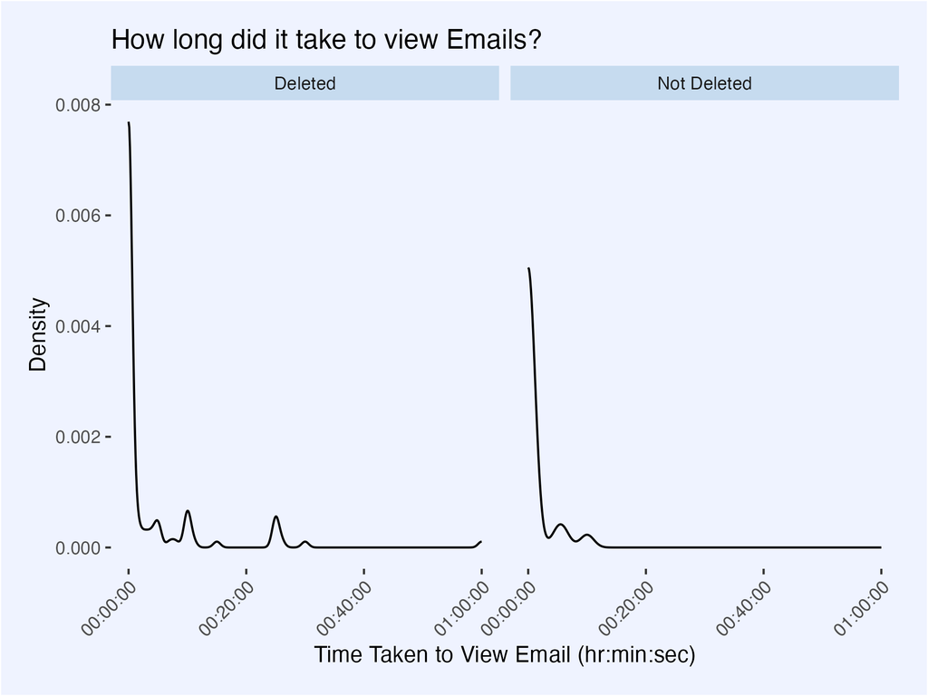

A figure split up into two plots, one about emails that were deleted and the other about those that weren’t deleted. Each plot is a density plot with the time taken to view an email on the x-axis and the density on the y-axis. Both plots show similiar shapes, heavily skewed to the right.

The significantly right-skewed distribution of both plots shows that I aim to view emails as soon as possible. Further shown by all visible emails being viewed within an hour. For emails that were not deleted, this cuts down to viewing these emails in less than 15-20 minutes, due to the importance signified by them not being deleted. A larger proportion of deleted emails were viewed immediately as shown by a higher peak at time = 0:00:00. This is because emails that I can tell are nonsense from the notification, I will delete directly from the notification, cutting down on the time and effort required.